# Cluster Analuses Project Danilova Elizaveta 163

*Students who does not work full time gain more than full time students, and relatively the same as non students

*The years of coding shows that non-students have more experience, and part-time tudents also have more experience that the current full time tudents, that is quite obviou and logical.

```r
ruser1 <- ruser %>% na.omit(ruser$money)
ruser2 <- ruser %>% na.omit(ruser$YearsCode)

tapply(log(ruser1$money), ruser1$Student,mean)
```

```
##             No Yes, full-time Yes, part-time
##           -Inf       12.03706       12.12782
```

```r
tapply(ruser1$money, ruser1$Student,mean)
```

```
##             No Yes, full-time Yes, part-time
##        2755781        1805380        2713862
```

```r
tapply(ruser2$YearsCode, ruser2$Student,mean)
```

```
##             No Yes, full-time Yes, part-time
##      13.565560       9.117647      11.232456
```

```r
tapply(ruser2$YearsCode, ruser2$OpSys,median)
```

```
##         BSD Linux-based       MacOS     Windows
##          18          10          10          10
```

The ditribution of money varible to dwmontrate the difference among tudents and Hobbyist

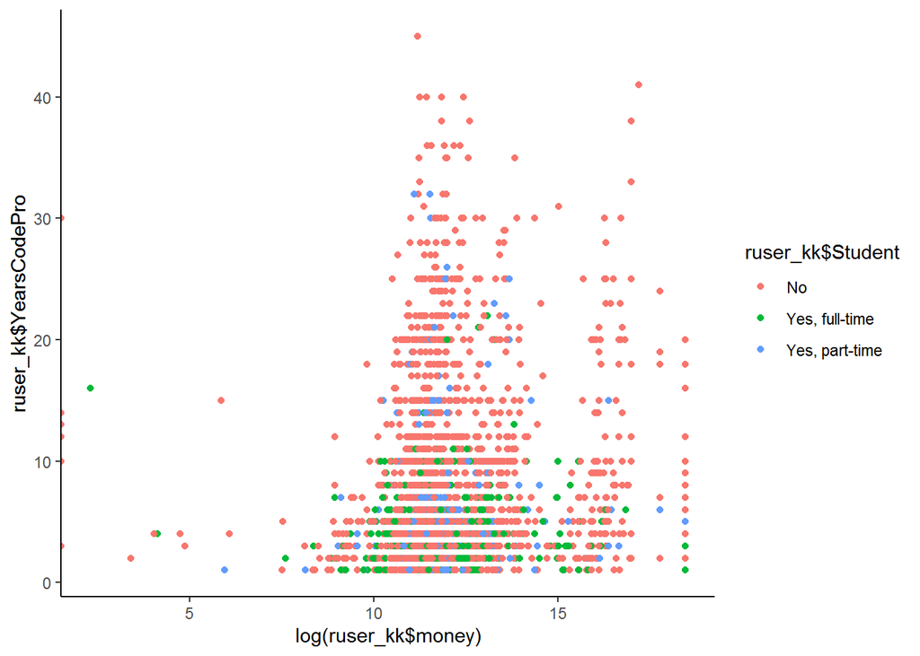

```r
library(ggplot2)
ggplot(ruser_kk, aes(log(ruser_kk$money), ruser_kk$YearsCodePro, color = ruser_kk$Student)) +
  geom_point() +
  theme_classic()
```

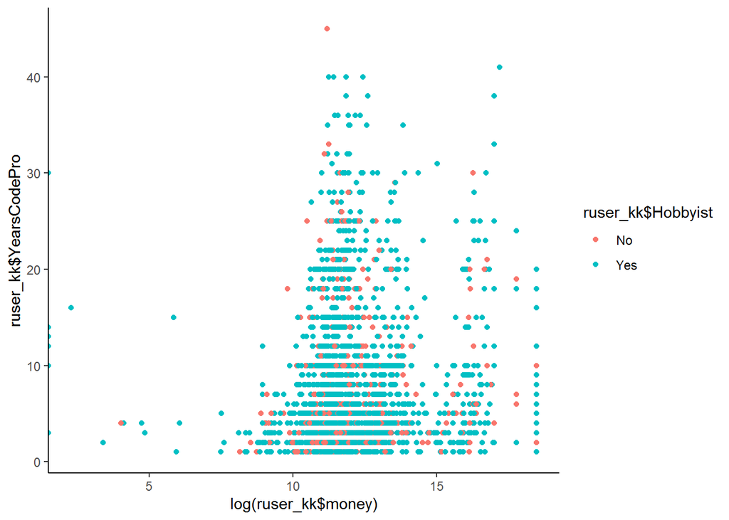

```r
library(ggplot2)
ggplot(ruser_kk, aes(log(ruser_kk$money), ruser_kk$YearsCodePro, color = ruser_kk$Hobbyist)) +
  geom_point() +
  theme_classic()
```

## K-means

For the k-means the variables YearsCode,money,YearsCodePro,Age1stCode,Age.

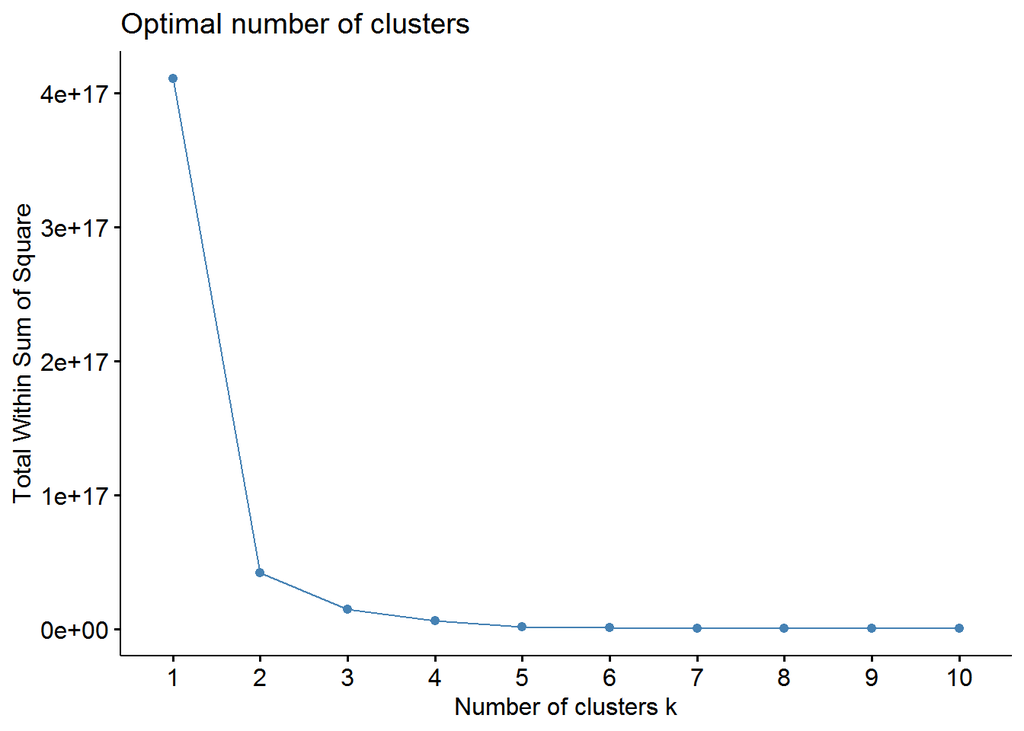

```r
library(factoextra)
library(cluster)
ruser_k <- ruser %>% select(YearsCode,money,YearsCodePro,Age1stCode,Age)
ruser_k <- ruser_k %>% na.omit()
fviz_nbclust(ruser_k[ , 1:5], kmeans, method = "wss")
```

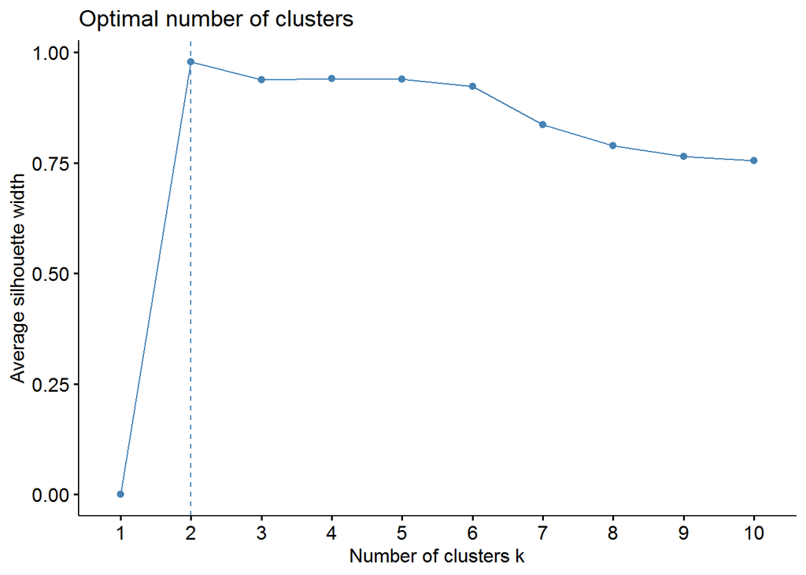

```r
fviz_nbclust(ruser_k[ , 1:5], kmeans, method = "silhouette")
```

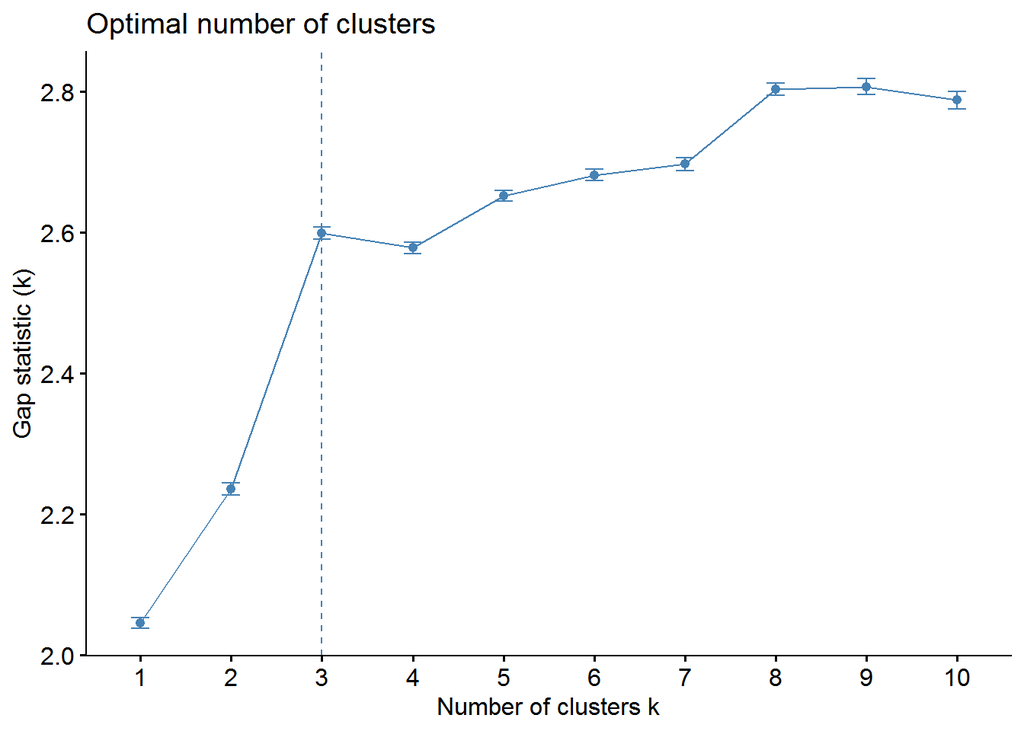

```r
fviz_nbclust(ruser_k[ , 1:5], kmeans, method = "gap")
```

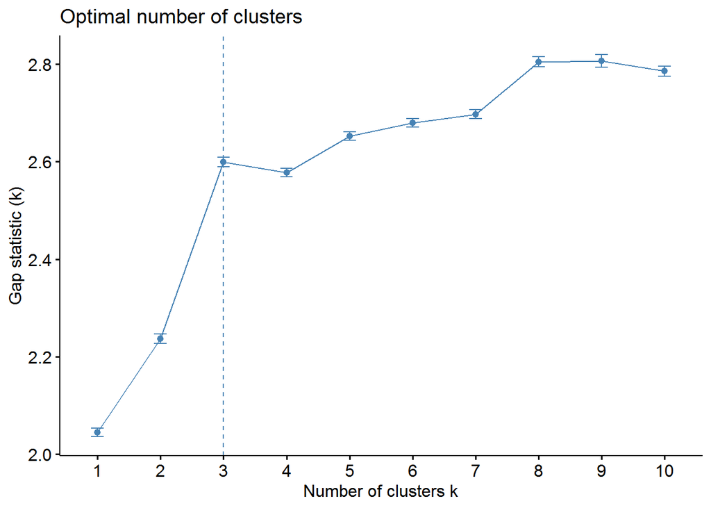

```r
fviz_nbclust(ruser_k[ , 1:2], kmeans, method = "gap")
```

#### Clusterizaton by 2 variables (YearsCode, money)

```r
set.seed(20)
ruserCluster <- kmeans(ruser_k[ , 1:2],
                      3,
                      nstart = 20
)

ruserCluster3 <- kmeans(ruser_k[ , 1:2],
                      6,
                      nstart = 20
)
```

With the division on 3 clusters there is a one mall cluster of profesional users that gain enough money but with different code experience, the big middle class of coders with common distribution of wealt and experience, and the cluster of “hobby” people or students, they have variou experience but low money gain

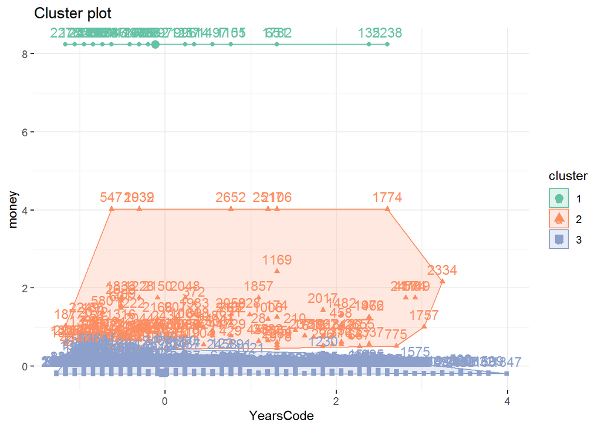

```r
fviz_cluster(ruserCluster, data = ruser_k[ , 1:2],
   palette = "Set2",
   ggtheme = theme_minimal())
```

The 6 clusters distribution separated the 2 lower big clusters by 2 and defined separately the common people in the middle green cluster

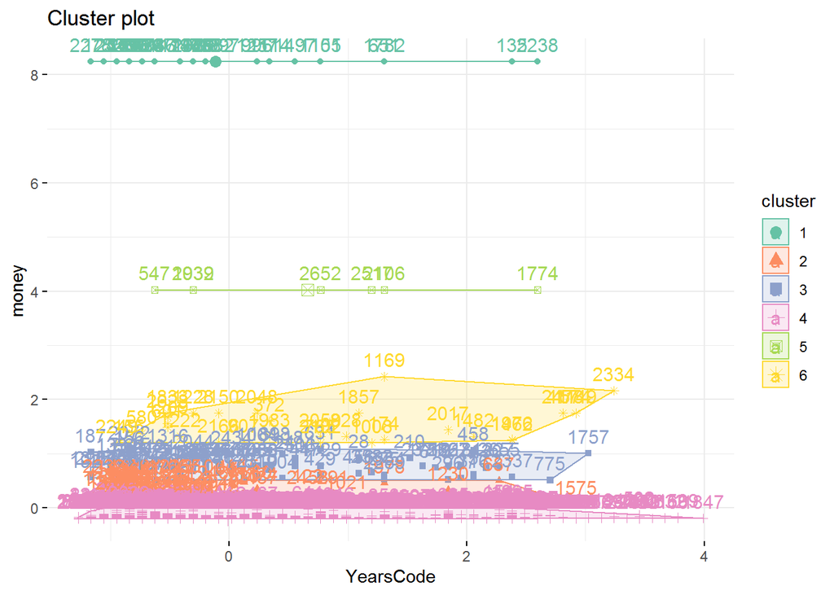

```r
fviz_cluster(ruserCluster3, data = ruser_k[ , 1:2],
   palette = "Set2",
   ggtheme = theme_minimal())
```

For the all 5 variables the 3 cluster distribution suits well,the defined previous cluster upper cluster i not the green at the bottom, wherea the blue and red clusters intersept , however ther are still could be detinguished

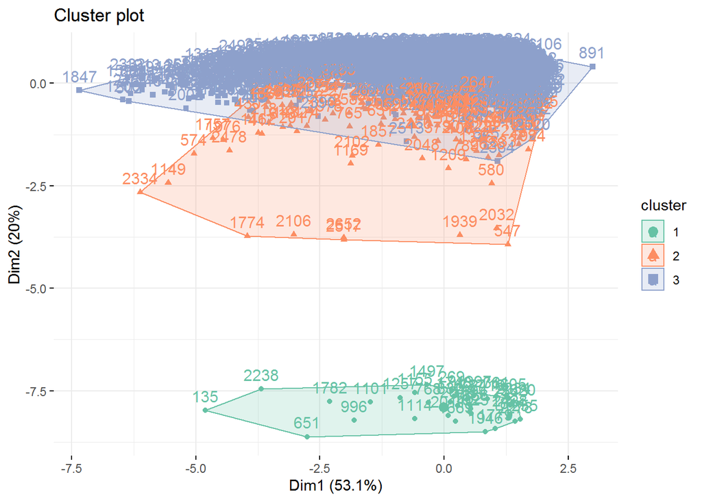

```r
fviz_cluster(ruserCluster, data = ruser_k[ , 1:5],
   palette = "Set2",
   ggtheme = theme_minimal())
```

# HIERARCHICAL: agnes - Agglomerative Hierarchical clustering algorithm

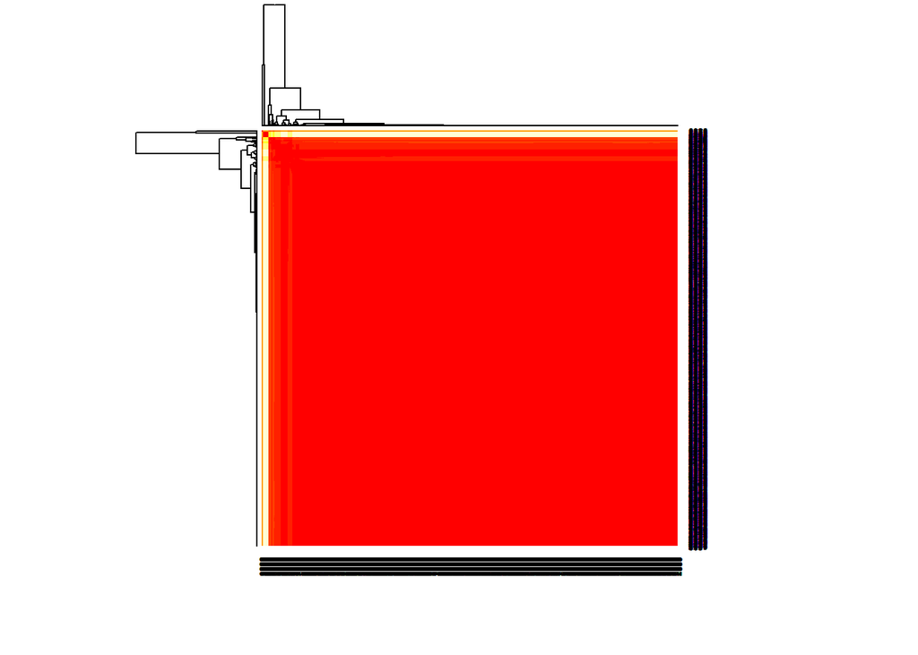

```r
ruser_k <- ruser_k %>% filter(Age > 14)
ruser_k <- ruser_k %>% filter(Age < 81)
r.use <- subset(ruser_k, select = -YearsCodePro)
d <- dist(ruser_k, method = 'euclidean') # calculate a distance matrix on selected variables

heatmap(as.matrix(d), symm = T,
        distfun = function(x) as.dist(x))
```

The heatmap shows the 2 cluster distribution

```r
library(cluster)
hfit_ward <- agnes(d, method = "ward") # principle: minimal average distance between clusters
hfit_average <- agnes(d, method = "average") # average distance between an observation and existing clusters
hfit_complete <- agnes(d, method = "complete") # maximal distance between an observation and existing clusters
```

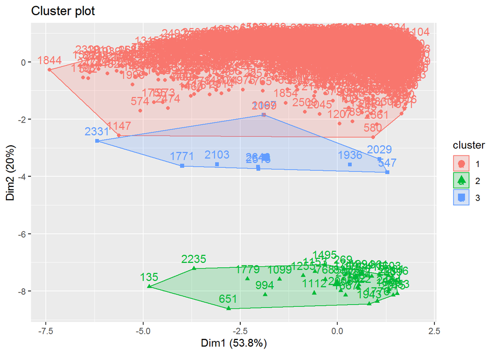

```r
h_avg_cut <- hcut(d, k = 3, hc_method = "average")
fviz_cluster(h_avg_cut, ruser_k , ellipse.type = "convex")
```

```r
h_avg_cut1 <- hcut(d, k = 3, hc_method = "ward")
```

```
## The "ward" method has been renamed to "ward.D"; note new "ward.D2"
```

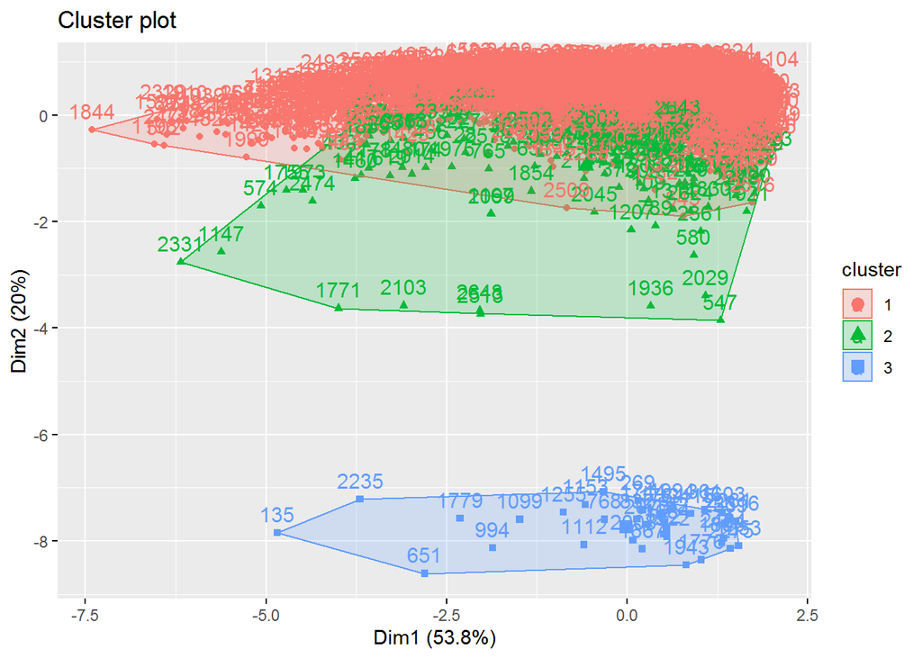

```r
fviz_cluster(h_avg_cut1, ruser_k , ellipse.type = "convex")
```

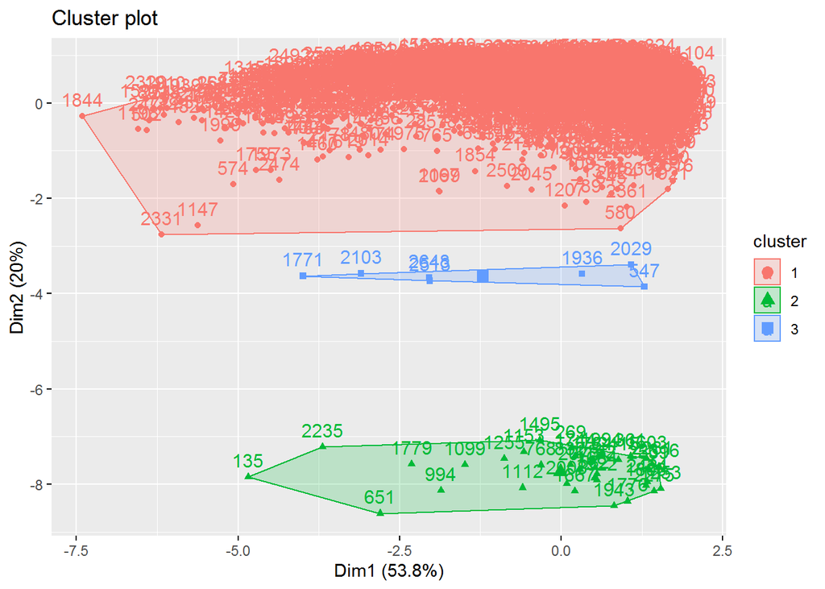

```r
h_avg_cut2 <- hcut(d, k = 3, hc_method = "complete")
fviz_cluster(h_avg_cut2, ruser_k , ellipse.type = "convex")
```

# Dendograms

```r
cl <- cutree(hfit_average, k = 3)

library(dplyr)
ruser_k <- mutate(ruser_k, cluster = cl)
head(ruser_k)
```

```
## # A tibble: 6 x 6
##   YearsCode   money YearsCodePro Age1stCode   Age cluster
##       <dbl>   <dbl>        <dbl>      <dbl> <dbl>   <int>
## 1        13 4397040            3         15    28       1
## 2         8  494928            4         17    38       1
## 3         6  100800            3         16    25       1
## 4        11  110000            8         19    30       1
## 5         7   66750            6         10    25       1
## 6        16   62000           11         17    34       1
```

The 3rd cluster have people with more coding experience and they significantly early tarted to code, the 1st and 2nd clusters are similar, bur the money gain is more in the 2nd clustes, it can be supposed to be the part-time students that previously shows more money gain but relatively the same experience with other students

```r
library(magrittr)
ruser_k[ ,-5] %>%
  group_by(cluster) %>%
  summarise_all(funs(mean(.)))
```

```
## # A tibble: 3 x 5
##   cluster YearsCode      money YearsCodePro Age1stCode
##     <int>     <dbl>      <dbl>        <dbl>      <dbl>
## 1       1      12.8    952108.         7.83       15.4
## 2       2      11.8 104000000          6.94       15.6
## 3       3      22.3  47266556.        14.7        12.9
```

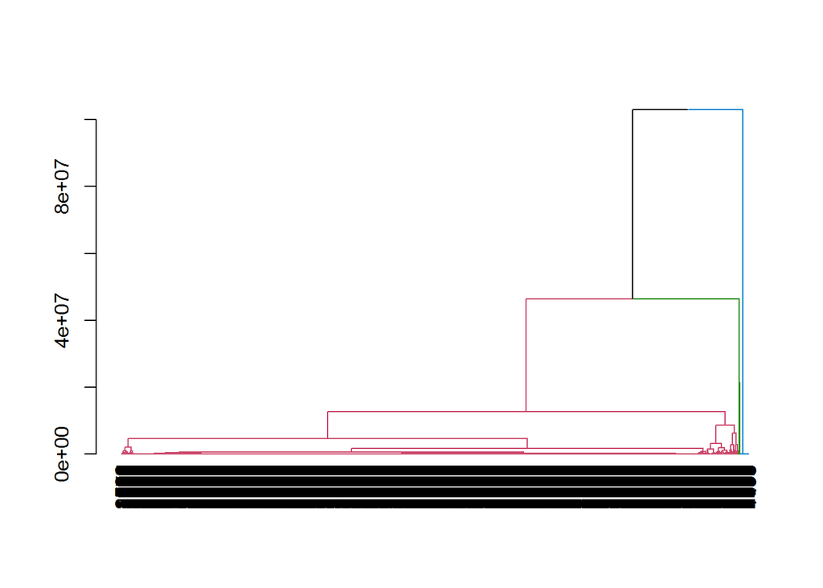

```r
#Average

library(dendextend)
dend <- as.dendrogram(hfit_average)
dend_col <- color_branches(dend, k = 3)
plot(dend_col)
```

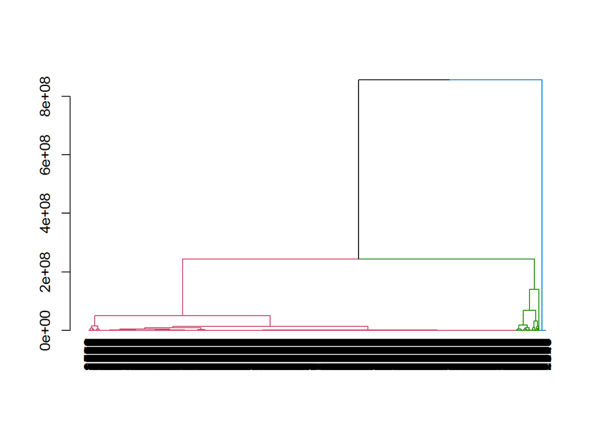

```r
#Ward
dend1 <- as.dendrogram(hfit_ward)
dend_col1 <- color_branches(dend1, k = 3)
plot(dend_col1)
```

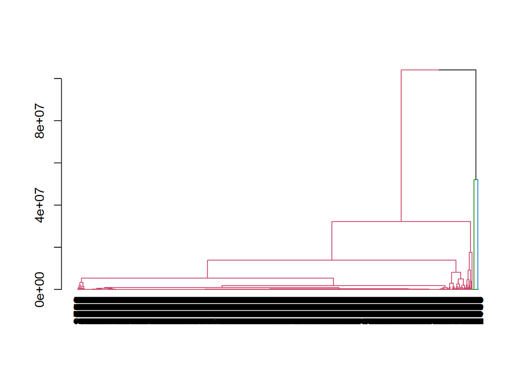

```r
dend2 <- as.dendrogram(hfit_complete)
dend_col2 <- color_branches(dend2, k = 3)
plot(dend_col2)
```

The dendograms shows the 2-3 cluster ditribution with the one big and similar inside cluster that is not broke with the increasinf the number of factors, whereas the small clusters are well defined and difference could be found further.The ward method of minimal average distance between clusters shows the best distribution

# Mixed type data

Preparation of the data, creating the new variable of code Experts- does the respondend a professional or nor, according to the histogram more than 6 years of coding professionally can be presented as an expert

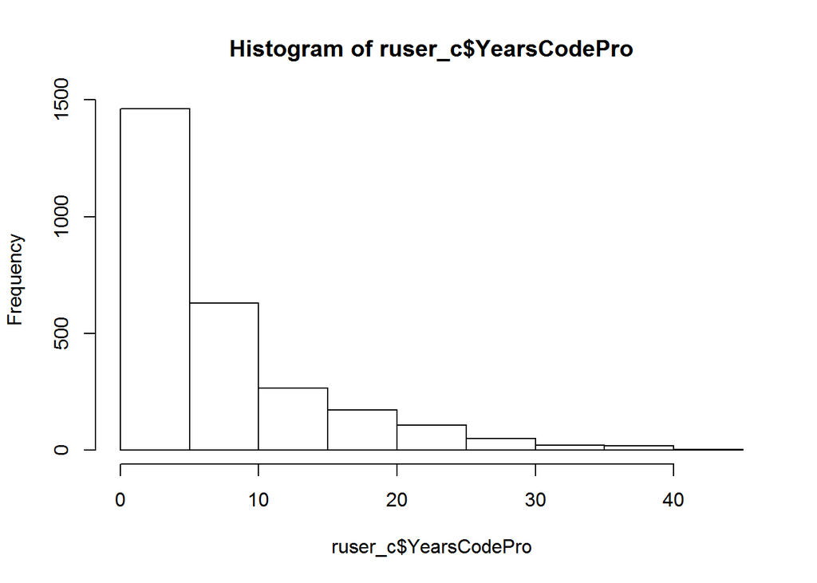

```r
set.seed(2020) # for reproducibility

library(ISLR)
library(Rtsne)
library(tidyverse)

ruser_c <- ruser %>% select(-ConvertedComp,-CompFreq,-YearsCode,-money)
ruser_c <- ruser_c %>% na.omit(YearsCodePro,Age1stCode)

hist(ruser_c$YearsCodePro)
```

```r
ruser_clean = ruser_c %>%
  mutate(
         isPro = cut(YearsCodePro,
                       breaks = c(0, 6, 40),
                       labels = c("Not Pro", "Pro"),
                       include.lowest = TRUE)) %>%
  mutate(isPro = factor(isPro))

#glimpse(ruser_clean)
```

### Gower ditance matrix

```r
library(cluster)
gower_dist <- daisy(ruser_clean[ , ],
                    metric = "gower",
                    type = list(logratio = 3))

summary(gower_dist)
```

```
## 3725085 dissimilarities, summarized :
##    Min. 1st Qu.  Median    Mean 3rd Qu.    Max.
##  0.0000  0.4471  0.5335  0.5244  0.5957  0.9415
## Metric :  mixed ;  Types = I, I, N, N, N, N, N, N, N, N, N, N, N, N, N, N, N, I, N
## Number of objects : 2730
```

```r
gower_mat <- as.matrix(gower_dist)

ruser_clean[
  which(gower_mat == min(gower_mat[gower_mat != min(gower_mat)]), # lowest of those not equal to zero
        arr.ind = TRUE)[1, ], ]
```

```
## # A tibble: 2 x 19
##   YearsCodePro Age1stCode MainBranch Hobbyist OpenSourcer Employment Country
##          <dbl>      <dbl> <fct>      <fct>    <fct>       <fct>      <fct>
## 1            2         13 I am a de… Yes      Never       Employed … United…
## 2            2         16 I am a de… Yes      Never       Employed … United…
## # … with 12 more variables: Student <fct>, EdLevel <fct>, UndergradMajor <fct>,
## #   JobSat <fct>, JobSeek <fct>, WorkPlan <fct>, WorkLoc <fct>, OpSys <fct>,
## #   Containers <fct>, SocialMedia <fct>, Age <dbl>, isPro <fct>
```

```r
# The most similar is the non  student worker with bachelor degree in the computer science that are fully-employed satisfied with the job, but with different experience in coding, similar age 23-24, working in office on Windows and do not use containers, and the Social network is Reddit.


ruser_clean[
  which(gower_mat == max(gower_mat[gower_mat != max(gower_mat)]),
        arr.ind = TRUE)[1, ], ] # arr.ind. = array indices, a logical variable
```

```
## # A tibble: 2 x 19
##   YearsCodePro Age1stCode MainBranch Hobbyist OpenSourcer Employment Country
##          <dbl>      <dbl> <fct>      <fct>    <fct>       <fct>      <fct>
## 1            1         19 I am a de… Yes      Less than … Employed … Canada
## 2           43         34 I am not … No       Never       Employed … Spain
## # … with 12 more variables: Student <fct>, EdLevel <fct>, UndergradMajor <fct>,
## #   JobSat <fct>, JobSeek <fct>, WorkPlan <fct>, WorkLoc <fct>, OpSys <fct>,
## #   Containers <fct>, SocialMedia <fct>, Age <dbl>, isPro <fct>
```

```r
# The most dissimilar workers have vwry differnt coding experience and major specialization(Web development/Math and statistics) and educational level, the job condidions are also, different(home/office), the unique, non common social media(WeChat,LinkedIn) and unique counties(Canada, Spain)
```

# Silhouette width

```r
sil_width <- c(NA)

for(i in 2:10){
  pam_fit <- pam(gower_dist,
                 diss = TRUE,
                 k = i)
  sil_width[i] <- pam_fit$silinfo$avg.width
}
```

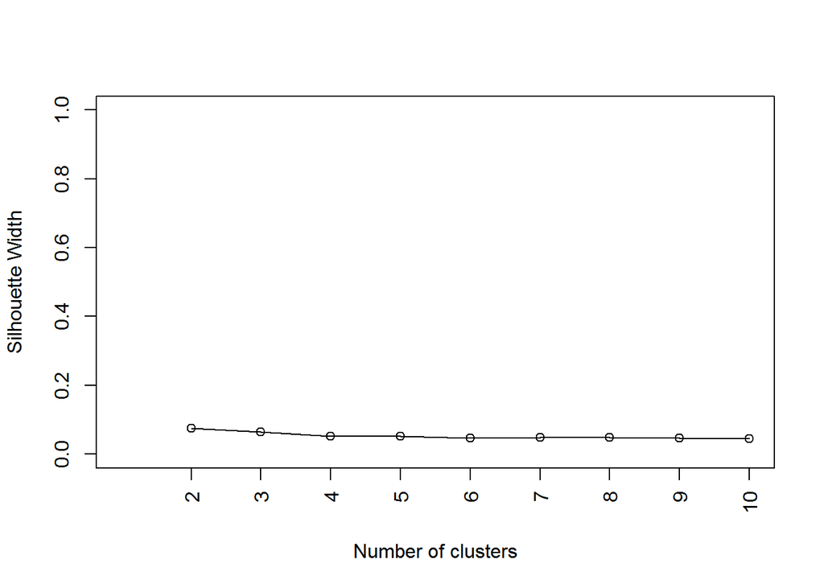

```r
plot(1:10, sil_width,
     xlab = "Number of clusters", xaxt='n',
     ylab = "Silhouette Width",
     ylim = c(0,1))
axis(1, at = seq(2, 10, by = 1), las=2)
lines(1:10, sil_width)
```

```r
pam_fit <- pam(gower_dist, diss = TRUE, k = 3)
pam_fit$data <- ruser_clean[ , ]
```

The silhouette width does not show there significant difference, there is onlu a slight increase in 2-3 clusters measure

## Clusters differences

```r
pam_results <- ruser_clean %>%
  dplyr::mutate(cluster = pam_fit$clustering) %>%
  group_by(cluster) %>%
  do(the_summary = summary(.))
pam_results$the_summary
```

```
## [[1]]
##   YearsCodePro      Age1stCode
##  Min.   : 1.000   Min.   : 5.00
##  1st Qu.: 2.000   1st Qu.:12.00
##  Median : 4.000   Median :15.00
##  Mean   : 5.811   Mean   :16.17
##  3rd Qu.: 6.000   3rd Qu.:19.00
##  Max.   :45.000   Max.   :40.00
##
##                                                                          MainBranch
##  I am a developer by profession                                               :142
##  I am a student who is learning to code                                       :  0
##  I am not primarily a developer, but I write code sometimes as part of my work:467
##  I code primarily as a hobby                                                  :  0
##  I used to be a developer by profession, but no longer am                     :  0
##
##
##  Hobbyist                                              OpenSourcer
##  No :145   Less than once a month but more than once per year: 96
##  Yes:464   Less than once per year                           :163
##            Never                                             :280
##            Once a month or more often                        : 70
##
##
##
##                                                 Employment
##  Employed full-time                                  :546
##  Employed part-time                                  : 25
##  Independent contractor, freelancer, or self-employed: 38
##  Not employed, and not looking for work              :  0
##  Not employed, but looking for work                  :  0
##  Retired                                             :  0
##
##            Country              Student
##  United States :207   No            :455
##  Germany       : 45   Yes, full-time: 97
##  United Kingdom: 41   Yes, part-time: 57
##  France        : 31
##  Netherlands   : 23
##  Canada        : 18
```

[output cut: 262 more lines]

```
##  I do not use containers                                              :285
##  Development;Testing;Production                                       :129
##  Development;Testing;Production;Outside of work, for personal projects:122
##  Development                                                          : 65
##  Development;Testing                                                  : 63
##  Outside of work, for personal projects                               : 62
##  (Other)                                                              :237
##    SocialMedia       Age            isPro        cluster
##  Twitter :299   Min.   :16.00   Not Pro:182   Min.   :3
##  WhatsApp:144   1st Qu.:30.00   Pro    :779   1st Qu.:3
##  Facebook:116   Median :35.00   NA's   :  2   Median :3
##  YouTube :115   Mean   :36.37                 Mean   :3
##  Reddit  : 89   3rd Qu.:41.00                 3rd Qu.:3
##  LinkedIn: 75   Max.   :67.00                 Max.   :3
##  (Other) :125
```

```r
ruser_clean$cluster <- as.factor(pam_fit$clustering)

ruser_clean[pam_fit$medoids, 1:9]
```

```
## # A tibble: 3 x 9
##   YearsCodePro Age1stCode MainBranch Hobbyist OpenSourcer Employment Country
##          <dbl>      <dbl> <fct>      <fct>    <fct>       <fct>      <fct>
## 1            2         12 I am not … Yes      Never       Employed … United…
## 2            2         14 I am a de… Yes      Never       Employed … United…
## 3           10         15 I am a de… Yes      Less than … Employed … United…
## # … with 2 more variables: Student <fct>, EdLevel <fct>
```

```r
ruser_clean[pam_fit$medoids, 10:18]
```

```
## # A tibble: 3 x 9
##   UndergradMajor JobSat JobSeek WorkPlan WorkLoc OpSys Containers SocialMedia
##   <fct>          <fct>  <fct>   <fct>    <fct>   <fct> <fct>      <fct>
## 1 Mathematics o… Sligh… I’m no… There's… Office  Wind… I do not … Facebook
## 2 Computer scie… Very … I’m no… There i… Office  Wind… I do not … Reddit
## 3 Computer scie… Sligh… I’m no… There i… Office  MacOS I do not … Twitter
## # … with 1 more variable: Age <dbl>
```

```r
ruser_clean[pam_fit$medoids, 19:20]
```

```
## # A tibble: 3 x 2
##   isPro   cluster
##   <fct>   <fct>
## 1 Not Pro 1
## 2 Not Pro 2
## 3 Pro     3
```

So, the

- 1st cluster :
- 4 years code professionally(Non Pro coders), median age of the first code 15, not a developer by profession ,full-employed,not students(455, having masters degree(the top :math/statistics and natural sciences), not looking for a job, working without schedule in office on Windows(364), not using containers and using Facebook and WhatsUp for communication, median age 30.
- 2nd cluster :
- 3 code professionally(Non Pro coders), median age of the first code 16, developer by profession, full-employed, most from US, but many India respondents, more students than in the 1t cluster, having bachelor degree with major in the computer science, satisfied with the job, not looking for a job but open for new opportunities, having work schedule, mostly office workers(working home-333), Linux and Windows based,do not use containers, using Reddit for communication, median age 27, slightly younger than 1st cluster. Taking into account age and that many respondents have bachelor degree there can be many students aiming for the master degree.
- 3rd cluster :
- 10 code professionally(Mostly Pro coders), median age of the first code 14, developer by profession, using open source more active, full-time employed, fewer students than in other clusters, masters degree in computer science, slightly satisfied with the job, mostly working with schedule in office, using equally Linux, Mac and Windows, using containers more than 1st and 2nd clusters, using Twitter for communication, median age 35

### Visualising the clusters

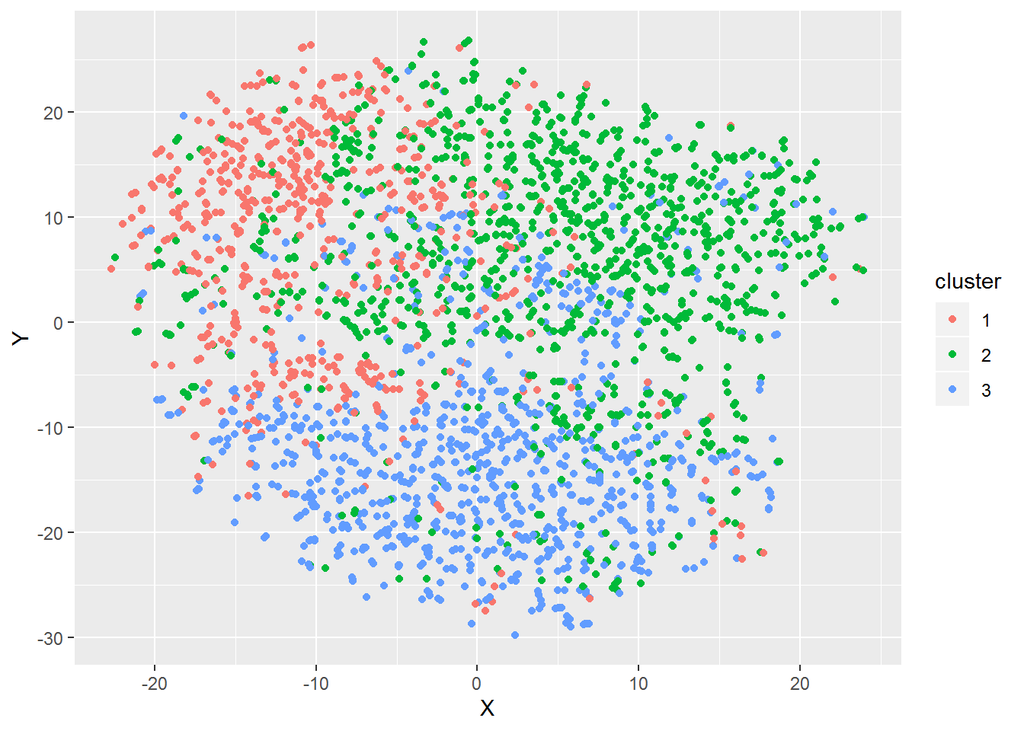

```r
set.seed(111)
library(Rtsne)

tsne_obj <- Rtsne(gower_dist, is_distance = TRUE)

tsne_data <- tsne_obj$Y %>% # $Y is a matrix containing the new representations for the objects
  data.frame() %>%
  setNames(c("X", "Y")) %>%
  mutate(cluster = factor(pam_fit$clustering))

ggplot(aes(x = X, y = Y), data = tsne_data) +
  geom_point(aes(color = cluster))
```

On the cluster visualization the cluster of pro-workers is more separate from others(blue one), while 1st and 2nd are close to each other but still can be destinguished.

Totally, clusters are distributed by professional coders with more working experience in technical staff and two clusters of not so professional coders which are different in educational pattern, work schedule and satisfaction. The younger developers are more satisfied with their job, not technical-computer major cluster repondents work without the schedule, so have more frilance activity, while developers by profesion have more strict working conditions.